# Project 8 Template

```r
# Add to this package list for additional SL algorithms
pacman::p_load(
  tidyverse,
  ggthemes,
  ltmle,
  tmle,
  SuperLearner,
  tidymodels,
  caret,
  dagitty,
  ggdag,
  here)
```

```r
heart <- readr::read_csv("/Users/saadaamadu/git/CSS2/CSS Forked/Projects/Project 8/heart_disease_tmle.csv")
library(dplyr)
library(tidyverse)

heart_prep <- heart %>%
  mutate(across(
    c(sex_at_birth, simplified_race, college_educ),
    as.factor
  ))
```

```r
# building design matrix
X <- model.matrix(
  mortality ~ blood_pressure_medication
    + age + sex_at_birth + simplified_race + college_educ
    + income_thousands + bmi + chol + blood_pressure
  - 1,
  data = heart_prep
)

# scale just the original numeric columns
num_cols <- c("age", "income_thousands", "bmi", "chol", "blood_pressure")
X[, num_cols] <- scale(X[, num_cols])

# outcome vector
Y <- heart_prep$mortality
```

```r
glimpse(heart)
```

```
## Rows: 10,000
## Columns: 14
## $ age                         <dbl> 32.92951, 53.92344, 65.33631, 16.82682, 56…
## $ sex_at_birth                <dbl> 0, 1, 1, 1, 1, 1, 1, 1, 1, 0, 0, 0, 0, 0, …
## $ simplified_race             <dbl> 1, 1, 3, 1, 1, 1, 1, 1, 3, 3, 3, 2, 1, 1, …
## $ college_educ                <dbl> 2, 2, 2, 2, 2, 2, 1, 1, 2, 1, 1, 2, 2, 2, …
## $ income_thousands            <dbl> 91.32660, 38.76890, 35.48435, 93.77726, 85…
## $ bmi                         <dbl> 27.09986, 27.61615, 27.52499, 24.88569, 22…
## $ blood_pressure              <dbl> 146.9862, 125.7578, 131.6789, 131.2926, 13…
## $ chol                        <dbl> 211.4630, 187.8418, 197.0794, 229.6352, 20…
## $ blood_pressure_medication   <dbl> 0, 0, 0, 0, 0, 0, 0, 0, 0, 0, 0, 1, 0, 0, …
## $ bmi_2                       <dbl> 27.08979, 27.61077, 27.52064, 24.89534, 22…
## $ blood_pressure_2            <dbl> 146.9800, 125.7505, 131.6626, 131.2765, 13…
## $ chol_2                      <dbl> 211.5343, 187.7360, 196.9674, 229.6558, 20…
## $ blood_pressure_medication_2 <dbl> 0, 0, 0, 0, 0, 0, 1, 0, 0, 0, 0, 0, 0, 0, …
## $ mortality                   <dbl> 1, 0, 1, 0, 0, 1, 1, 1, 1, 1, 0, 0, 0, 1, …
```

# Introduction

Heart disease is the leading cause of death in the United States, and treating it properly is an important public health goal. However, it is a complex disease with several different risk factors and potential treatments. Physicians typically recommend changes in diet, increased exercise, and/or medication to treat symptoms, but it is difficult to determine how effective any one of these factors is in treating the disease. In this project, you will explore SuperLearner, Targeted Maximum Likelihood Estimation (TMLE), and Longitudinal Targeted Maximum Likelihood Estimation (LTMLE). Using a simulated dataset, you will explore whether taking blood pressure medication reduces mortality risk.

# Data

For the “SuperLearner” and “TMLE” portions, you can ignore any variable that ends in “_2”, we will reintroduce these for LTMLE.

# SuperLearner

## Modeling

Fit a SuperLearner model to estimate the probability of someone dying from complications of heart disease, conditional on treatment and the relevant covariates. Do the following:

```r
# Define SL library
SL.library <- c(
  "SL.glm",     # logistic regression
  "SL.glmnet",  # elastic-net
  "SL.ranger",  # random forest
  "SL.xgboost", # gradient boosting
  "SL.nnet"     # neural network
)
```

```r
# 70/30 train/test split
set.seed(789)
train_idx <- sample(seq_len(nrow(X)), size = floor(0.7 * nrow(X)))
X_train   <- X[train_idx, ]
X_test    <- X[-train_idx, ]
Y_train   <- Y[train_idx]
Y_test    <- Y[-train_idx]
```

```r
# Fit SuperLearner on training data
set.seed(123)
sl_fit <- SuperLearner(
  Y          = Y_train,
  X          = X_train,
  family     = binomial(),
  SL.library = SL.library,
  method     = "method.NNLS",
  verbose    = TRUE
)
```

[output not shown]

[output not shown]

[output not shown]

[output not shown]

[output not shown]

[output not shown]

[output not shown]

[output not shown]

[output not shown]

[output not shown]

[output not shown]

[output not shown]

[output not shown]

[output not shown]

[output not shown]

[output not shown]

[output not shown]

[output not shown]

[output not shown]

[output not shown]

[output not shown]

[output not shown]

[output not shown]

[output not shown]

[output not shown]

[output not shown]

[output not shown]

[output not shown]

[output not shown]

[output not shown]

[output not shown]

[output not shown]

[output not shown]

[output not shown]

[output not shown]

[output not shown]

[output not shown]

[output not shown]

[output not shown]

[output not shown]

[output not shown]

[output not shown]

[output not shown]

[output not shown]

[output not shown]

[output not shown]

[output not shown]

[output not shown]

[output not shown]

[output not shown]

[output not shown]

[output not shown]

[output not shown]

[output not shown]

[output not shown]

[output not shown]

[output not shown]

[output not shown]

[output not shown]

[output not shown]

[output not shown]

[output not shown]

[output not shown]

[output not shown]

[output not shown]

[output not shown]

[output not shown]

```r
# CV risks & ensemble weights
cv_risks <- sl_fit$cvRisk
weights  <- sl_fit$coef

risk_coef_tbl <- tibble(
  Learner = names(cv_risks),
  CV_Risk = round(cv_risks, 4),
  Weight  = round(weights,    4)
) %>% arrange(desc(Weight))

knitr::kable(
  risk_coef_tbl,
  caption = "SuperLearner CV Risks & Ensemble Weights (Training Set)"
)
```

SuperLearner CV Risks & Ensemble Weights (Training Set)

| Learner | CV_Risk | Weight |
| --- | --- | --- |
| SL.ranger_All | 0.2317 | 0.4662 |
| SL.nnet_All | 0.2325 | 0.3963 |
| SL.glmnet_All | 0.2358 | 0.1375 |
| SL.glm_All | 0.2362 | 0.0000 |
| SL.xgboost_All | 0.2528 | 0.0000 |

```r
# Evaluate ensemble on held-out test set
library(caret)

# Predict probabilities on X_test
preds <- predict(
  sl_fit,
  newdata = X_test,
  onlySL  = FALSE
)
```

```r
# Build ensemble class labels
ens_pred <- factor(
  ifelse(preds$pred > 0.5, 1, 0),
  levels = c(0,1)
)

# Sanity-check
stopifnot(length(ens_pred) == length(Y_test))
```

```r
# Compute confusion matrix & extract metrics
cm_ens <- confusionMatrix(
  ens_pred,
  factor(Y_test, levels = c(0,1)),
  positive = "1"
)

ens_metrics <- c(
  Accuracy    = cm_ens$overall["Accuracy"],
  Sensitivity = cm_ens$byClass["Sensitivity"],
  Precision   = cm_ens$byClass["Precision"]
)
```

```r
# Display the results
knitr::kable(
  as.data.frame(t(round(ens_metrics,4))),
  caption = "Ensemble SL Performance on Test Set"
)
```

Ensemble SL Performance on Test Set

| Accuracy.Accuracy | Sensitivity.Sensitivity | Precision.Precision |
| --- | --- | --- |
| 0.5923 | 0.9241 | 0.5582 |

## Discussion Questions

The key advantage of the SuperLearner ensemble is that it combines multiple algorithms, weighting each according to its cross‐validated performance, rather than relying on a single “best” learner. By averaging over many learners, the ensemble smooths out the idiosyncratic errors of any one algorithm, leading to more stable predictions. Some learners may underfit while others overfit; the ensemble can balance these tendencies. If one algorithm is mis‐specified or performs poorly on a particular region of the data, other learners can compensate, so less vulnerability to the failure of any single method. In contrast, the discrete winner simply picks the single algorithm with lowest CV risk, discarding all other information and exposing you to its unique blind spots.

# Targeted Maximum Likelihood Estimation

## Causal Diagram

Using ggdag and daggity, draw a directed acylcic graph (DAG) that describes the relationships between the outcome, treatment, and covariates/predictors. Note, if you think there are covariates that are not related to other variables in the dataset, note this by either including them as freestanding nodes or by omitting them and noting omissions in your discussion.

```r
# DAG for TMLE

#loading library
library(dagitty)
library(ggdag)
library(ggplot2)
```

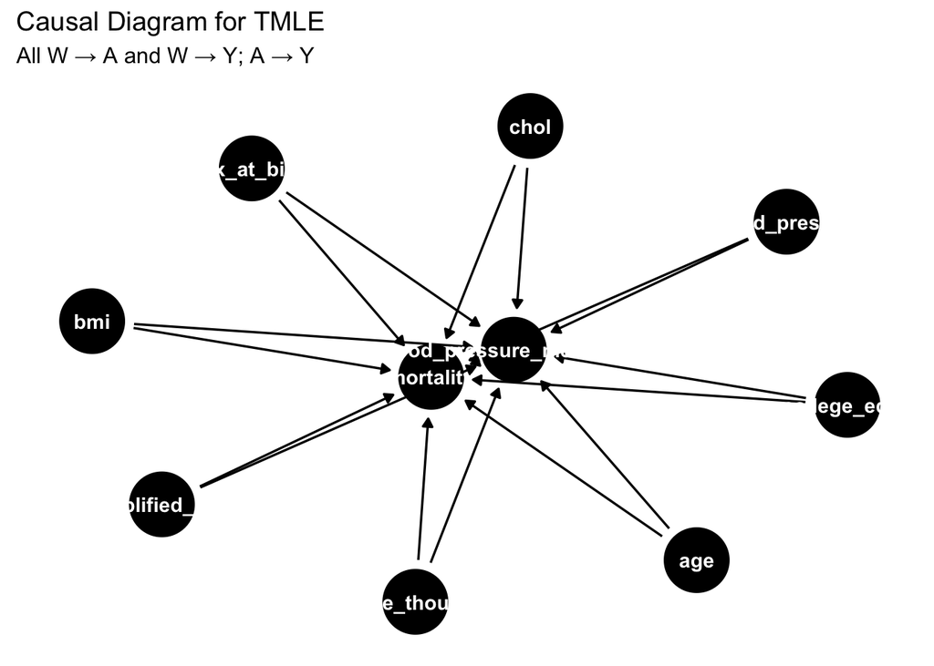

```r
#define the DAG
dag <- dagify(
  mortality ~ blood_pressure_medication
               + age + sex_at_birth + simplified_race
               + income_thousands + college_educ
               + bmi + chol + blood_pressure,
  blood_pressure_medication ~ age + sex_at_birth + simplified_race
                               + income_thousands + college_educ
                               + bmi + chol + blood_pressure,
  exposure = "blood_pressure_medication",
  outcome  = "mortality"
)

ggdag(dag) +
  theme_dag() +
  labs(
    title    = "Causal Diagram for TMLE",
    subtitle = "All W → A and W → Y; A → Y"
  )
```

## TMLE Estimation

Use the `tmle` package to estimate a model for the effect of blood pressure medication on the probability of mortality. Do the following:

```r
train_df <- heart_prep[ train_idx, ]
```

```r
#Define A_train, Y_train, W_train
A_train <- train_df$blood_pressure_medication
Y_train <- train_df$mortality
```

```r
W_train <- train_df %>%
  select(
    age,
    sex_at_birth,
    simplified_race,
    income_thousands,
    college_educ,
    bmi,
    chol,
    blood_pressure
  )
```

```r
library(tmle)

tmle_fit_simple <- tmle(
  Y             = Y_train,
  A             = A_train,
  W             = W_train,
  Q.SL.library  = c("SL.glm"),
  g.SL.library  = c("SL.glm"),
  family        = "binomial"
)
```

```r
# Extract ATE and CI
ate     <- tmle_fit_simple$estimates$ATE$psi
ate_se  <- sqrt(tmle_fit_simple$estimates$ATE$var.psi)
ate_ci  <- tmle_fit_simple$estimates$ATE$CI
```

```r
# Report
knitr::kable(
  data.frame(
    ATE        = round(ate,    3),
    SE         = round(ate_se, 3),
    `95% CI L` = round(ate_ci[1], 3),
    `95% CI U` = round(ate_ci[2], 3)
  ),
  caption = "TMLE Estimate of ATE (Medication → Mortality)"
)
```

TMLE Estimate of ATE (Medication → Mortality)

| ATE | SE | X95..CI.L | X95..CI.U |
| --- | --- | --- | --- |
| -0.352 | 0.014 | -0.379 | -0.326 |

# LTMLE Estimation

Now imagine that everything you measured up until now was in “time period 1”. Some people either choose not to or otherwise lack access to medication in that time period, but do start taking the medication in time period 2. Imagine we measure covariates like BMI, blood pressure, and cholesterol at that time for everyone in the study (indicated by a “_2” after the covariate name).

```r
# Re‐define a data.frame
ltmle_df <- heart %>%
  mutate(
    sex_at_birth      = as.factor(sex_at_birth),
    simplified_race   = as.factor(simplified_race),
    college_educ      = as.factor(college_educ)
  ) %>%

   select(
    # baseline
    blood_pressure_medication, age, sex_at_birth, simplified_race,
    income_thousands, college_educ, bmi, chol, blood_pressure,
    # time‐2
    blood_pressure_medication_2, bmi_2, chol_2, blood_pressure_2,
    # final outcome
    mortality
  )
```

## Causal Diagram

Update your causal diagram to incorporate this new information. : If your groups divides up sections and someone is working on LTMLE separately from TMLE then just draw a causal diagram even if it does not match the one you specified above.

: Check out slide 27 from Maya’s lecture, or slides 15-17 from Dave’s second slide deck in week 8 on matching.

: Keep in mind that any of the variables that end in “_2” are likely affected by both the previous covariates and the first treatment when drawing your DAG.

[figure not shown]

```r
# DAG for TMLE

dag_ltmle <- dagify(
  # edges to A0 and A1
  blood_pressure_medication   ~ age + sex_at_birth + simplified_race + income_thousands + college_educ + bmi + chol + blood_pressure,
  blood_pressure_medication_2 ~ blood_pressure_medication + bmi + chol + blood_pressure + age + sex_at_birth + simplified_race + income_thousands + college_educ + bmi_2 + chol_2 + blood_pressure_2,
  # edges to intermediate covariates L1
  bmi_2           ~ blood_pressure_medication + bmi + age + sex_at_birth + simplified_race + income_thousands + college_educ,
  chol_2          ~ blood_pressure_medication + chol + age + sex_at_birth + simplified_race + income_thousands + college_educ,
  blood_pressure_2~ blood_pressure_medication + blood_pressure + age + sex_at_birth + simplified_race + income_thousands + college_educ,
  # edges to final outcome
  mortality       ~ blood_pressure_medication + blood_pressure_medication_2 + bmi_2 + chol_2 + blood_pressure_2 +
                    age + sex_at_birth + simplified_race + income_thousands + college_educ,
  exposure        = c("blood_pressure_medication","blood_pressure_medication_2"),
  outcome         = "mortality"
)

ggdag(dag_ltmle) +
  theme_dag() +
  labs(
    title    = "Longitudinal DAG for LTMLE",
    subtitle = "A₀→L₁→A₁→Y with baseline W→{A₀,L₁,Y}"
  )
```

```r
ltmle_df <- heart_prep %>%
  select(
    blood_pressure_medication, age, sex_at_birth, simplified_race,
    income_thousands, college_educ, bmi, chol, blood_pressure,
    blood_pressure_medication_2, bmi_2, chol_2, blood_pressure_2,
    mortality
  )
```

```r
dummies <- model.matrix(
  ~ sex_at_birth + simplified_race + college_educ - 1,
  data = ltmle_df
)

ltmle_df <- bind_cols(
  ltmle_df %>% select(-sex_at_birth, -simplified_race, -college_educ),
  as_tibble(dummies)
)

ltmle_df <- ltmle_df %>% relocate(mortality, .after = last_col())
```

```r
# treatment nodes (same as before)
Anodes <- c("blood_pressure_medication", "blood_pressure_medication_2")

# everything except A-nodes and Y-node
Lnodes <- setdiff(
  names(ltmle_df),
  c(Anodes, "mortality")
)

Ynodes <- "mortality"
```

```r
# Naïve logistic‐regression estimate of risk under each static regimen
glm_naive <- glm(
  mortality ~ blood_pressure_medication + blood_pressure_medication_2,
  family = binomial(),
  data   = ltmle_df
)

# Predict under “always” (A0=1, A1=1) and “never” (A0=0, A1=0):
df_always <- ltmle_df %>% mutate(blood_pressure_medication = 1,
                                 blood_pressure_medication_2 = 1)
df_never  <- ltmle_df %>% mutate(blood_pressure_medication = 0,
                                 blood_pressure_medication_2 = 0)

risk_always_naive <- mean(predict(glm_naive, newdata = df_always, type="response"))
risk_never_naive  <- mean(predict(glm_naive, newdata = df_never,  type="response"))
ate_naive         <- risk_always_naive - risk_never_naive

knitr::kable(
  tibble(
    Risk_Always = round(risk_always_naive, 3),
    Risk_Never  = round(risk_never_naive,  3),
    ATE         = round(ate_naive,         3)
  ),
  caption = "Naïve Risk & ATE (ignoring time‐dependent confounding)"
)
```

Naïve Risk & ATE (ignoring time‐dependent confounding)

| Risk_Always | Risk_Never | ATE |
| --- | --- | --- |
| 0.25 | 0.566 | -0.316 |

```r
library(ltmle)

# Always-treated
ltmle_always <- ltmle(
  data            = ltmle_df,
  Anodes          = Anodes,
  Lnodes          = Lnodes,
  Ynodes          = Ynodes,
  abar            = rep(1, length(Anodes)),
  SL.library      = c("SL.glm"),
  survivalOutcome = FALSE
)
```

[output not shown]

```
## formula for age:
```

```
## Q.kplus1 ~ blood_pressure_medication
```

```
## formula for bmi_2:
```

```
## Q.kplus1 ~ blood_pressure_medication + age + income_thousands +     bmi + chol + blood_pressure + blood_pressure_medication_2
```

```
## gform not specified, using defaults:
```

```
## formula for blood_pressure_medication:
```

```
## blood_pressure_medication ~ 1
```

```
## formula for blood_pressure_medication_2:
```

```
## blood_pressure_medication_2 ~ blood_pressure_medication + age +     income_thousands + bmi + chol + blood_pressure
```

```
## Estimate of time to completion: < 1 minute
```

```r
# Never-treated
ltmle_never <- ltmle(
  data            = ltmle_df,
  Anodes          = Anodes,
  Lnodes          = Lnodes,
  Ynodes          = Ynodes,
  abar            = rep(0, length(Anodes)),
  SL.library      = c("SL.glm"),
  survivalOutcome = FALSE
)
```

[output not shown]

```
## formula for age:
```

```
## Q.kplus1 ~ blood_pressure_medication
```

```
## formula for bmi_2:
```

```
## Q.kplus1 ~ blood_pressure_medication + age + income_thousands +     bmi + chol + blood_pressure + blood_pressure_medication_2
```

```
## gform not specified, using defaults:
```

```
## formula for blood_pressure_medication:
```

```
## blood_pressure_medication ~ 1
```

```
## formula for blood_pressure_medication_2:
```

```
## blood_pressure_medication_2 ~ blood_pressure_medication + age +     income_thousands + bmi + chol + blood_pressure
```

```
## Estimate of time to completion: < 1 minute
```

```r
# Extract adjusted risks and compute ATE

risk_always <- as.numeric(summary(ltmle_always)$effect.measures$risk$estimate)
risk_never  <- as.numeric(summary(ltmle_never)$effect.measures$risk$estimate)
ate_ltmle   <- risk_always - risk_never

library(knitr)
library(tibble)

knitr::kable(
  tibble::tibble(
    Risk_Always = round(risk_always, 3),
    Risk_Never  = round(risk_never,  3),
    ATE         = round(ate_ltmle,   3)
  ),
  caption = "LTMLE Risk & ATE (adjusted for time-dependent confounding)"
)
```

LTMLE Risk & ATE (adjusted for time-dependent confounding)

[output not shown]

## LTMLE Estimation

Use the `ltmle` package for this section. First fit a “naive model” that control for the time-dependent confounding. Then run a LTMLE model that does control for any time dependent confounding. Follow the same steps as in the TMLE section. Do you see a difference between the two estimates?

```r
## Naive Model (no time-dependent confounding) estimate
glm_naive <- glm(
  mortality ~ blood_pressure_medication + blood_pressure_medication_2,
  family = binomial(),
  data   = ltmle_df
)

# predict under always (A0=1,A1=1) and never (A0=0,A1=0)
df_always <- ltmle_df %>%
  mutate(blood_pressure_medication   = 1,
         blood_pressure_medication_2 = 1)
df_never  <- ltmle_df %>%
  mutate(blood_pressure_medication   = 0,
         blood_pressure_medication_2 = 0)
risk_always_naive <- mean(predict(glm_naive, newdata = df_always, type = "response"))
risk_never_naive  <- mean(predict(glm_naive, newdata = df_never,  type = "response"))
ate_naive         <- risk_always_naive - risk_never_naive

knitr::kable(
  tibble(
    Risk_Always = round(risk_always_naive, 3),
    Risk_Never  = round(risk_never_naive,  3),
    ATE         = round(ate_naive,         3)
  ),
  caption = "Naïve Risk & ATE (ignoring time‐dependent confounding)"
)
```

Naïve Risk & ATE (ignoring time‐dependent confounding)

| Risk_Always | Risk_Never | ATE |
| --- | --- | --- |
| 0.25 | 0.566 | -0.316 |

## LTMLE estimate

```r
# ltmle_always <- ltmle(
  #data            = ltmle_df,
  #Anodes          = Anodes,
  #Lnodes          = Lnodes,
  #Ynodes          = Ynodes,
  #abar            = rep(1, length(Anodes)),
  #SL.library      = SL.library,
  #survivalOutcome = FALSE
#)
```

```r
#ltmle_never <- ltmle(
 # data            = ltmle_df,
  #Anodes          = Anodes,
  #Lnodes          = Lnodes,
  #Ynodes          = Ynodes,
  #abar            = rep(0, length(Anodes)),  # never treated
  #SL.library      = SL.library,
  #survivalOutcome = FALSE
#)
```

```r
risk_always_ltmle <- as.numeric(summary(ltmle_always)$effect.measures$risk$estimate)
risk_never_ltmle  <- as.numeric(summary(ltmle_never)$effect.measures$risk$estimate)
ate_ltmle         <- risk_always_ltmle - risk_never_ltmle

knitr::kable(
  tibble(
    Risk_Always = round(risk_always_ltmle, 3),
    Risk_Never  = round(risk_never_ltmle,  3),
    ATE         = round(ate_ltmle,         3)
  ),
  caption = "LTMLE Risk & ATE (adjusted for time‐dependent confounding)"
)
```

LTMLE Risk & ATE (adjusted for time‐dependent confounding)

[output not shown]

## Discussion Questions

A time-dependent confounder at time t is a variable Lₜ that is caused by earlier treatment(s),itself affects the later treatment, and is a cause of the outcome Y. In this study, blood_pressure_2 is textbook: prior treatment A₀ = blood_pressure_medication may itself lower your blood pressure by time 2. blood_pressure_2 reading influences whether your physician prescribes (or you elect to take) medication in period 2 (A₁). And blood_pressure_2 is a strong predictor of mortality. Age is increasing over time, but it’s not a time-dependent confounder in the same sense, because Age₁ doesn’t get “pulled around” by your blood-pressure medication. Thus Age₂ is not a child of A₀ in the DAG. You can safely adjust for age at either time point without worrying about inducing bias, because it does not lie on the causal pathway from prior treatment to later treatment to outcome.